# ARDF SSD EDA

Nyssa Tucker

2023-02-01

# 1 Motivation

The purpose of this document is to record initial EDA for ARDF data prior to curation and modeling. Below I consider what is present in the dataset, and manipulate the data into the below shape.

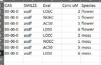

table format

# 2 Intake overview

## 2.1 Present or absent species groups

| var1 | Algae | Amphibians | Birds | Crustaceans | Fish | Flower | Fungi | Insect | Invertebrates | Mammals | Molluscs | Moss | Reptiles | Worms |
| --- | --- | --- | --- | --- | --- | --- | --- | --- | --- | --- | --- | --- | --- | --- |
| EC50 | 1 | 1 | 1 | 1 | 1 | 1 | 1 | 1 | 1 | 1 | 1 | 1 | 1 | 1 |
| LC50 | 1 | 1 | 1 | 1 | 1 | 1 | 1 | 1 | 1 | 1 | 1 | 0 | 1 | 1 |
| LOEC | 1 | 1 | 1 | 1 | 1 | 1 | 1 | 1 | 1 | 1 | 1 | 1 | 1 | 1 |
| NOEC | 1 | 1 | 1 | 1 | 1 | 1 | 1 | 1 | 1 | 1 | 1 | 1 | 1 | 1 |

## 2.2 Composition (Frequency + heatmap)

### 2.2.1 Frequency of species group entries * endpoint

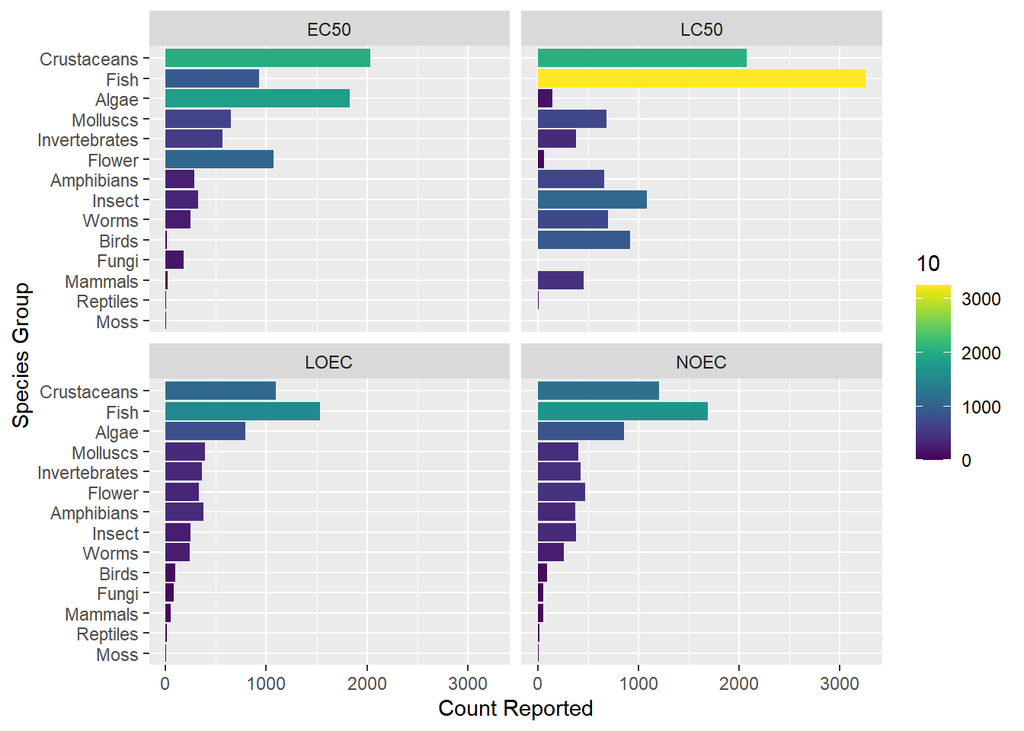

### 2.2.2 clusters

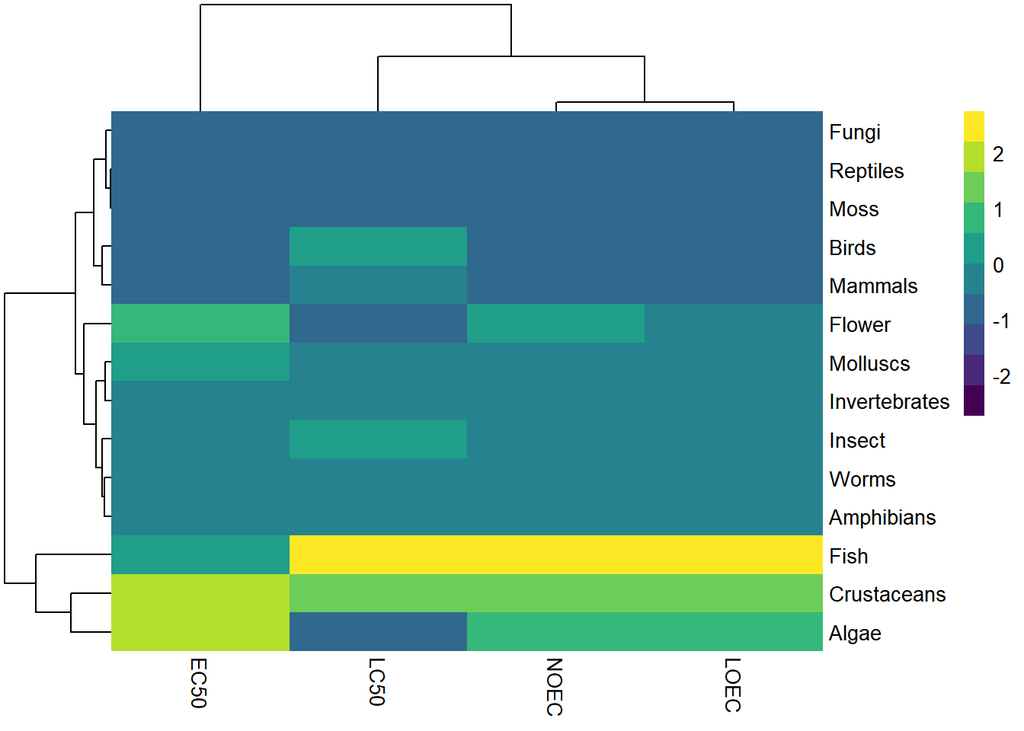

## 2.3 Final format

|  | CAS | CAS_no | Spec_group | Spec | type | ep_type | measured_val |
| --- | --- | --- | --- | --- | --- | --- | --- |
| 11062 | 9004959 | 9004-95-9 | Crustaceans | Crangon crangon | Acute | LC50 | 3.531783 |
| 17287 | 1746812 | 1746-81-2 | Molluscs | Lymnaea stagnalis | Acute | LC50 | 3.402314 |
| 10210 | 119335 | 119-33-5 | Crustaceans | Daphnia magna | Acute | LC50 | 3.071137 |
| 27953 | 221205909 | 221205-90-9 | Insect | Apis mellifera | Chron | NOEC | 2.906625 |
| 19885 | 55814410 | 55814-41-0 | Crustaceans | Daphnia magna | Chron | LOEC | 5.129275 |
| 18754 | 639587 | 639-58-7 | Amphibians | Xenopus tropicalis | Chron | LOEC | 8.108857 |

# 3 Data overview

There are a total of `30549` rows in this final dataset of which , `11285` have all the information annotated and `19264` are missing SMILES.  
This represents a fail rate of `63.1 %` .

There are `6573` unique CAS identified compounds in this dataset across `14` groups. Some groups have fewer than 50 compounds entered, which will be removed.

## 3.1 Chem represenetation

### 3.1.1 chem per endpoint

```
## [1] "EC50"
```

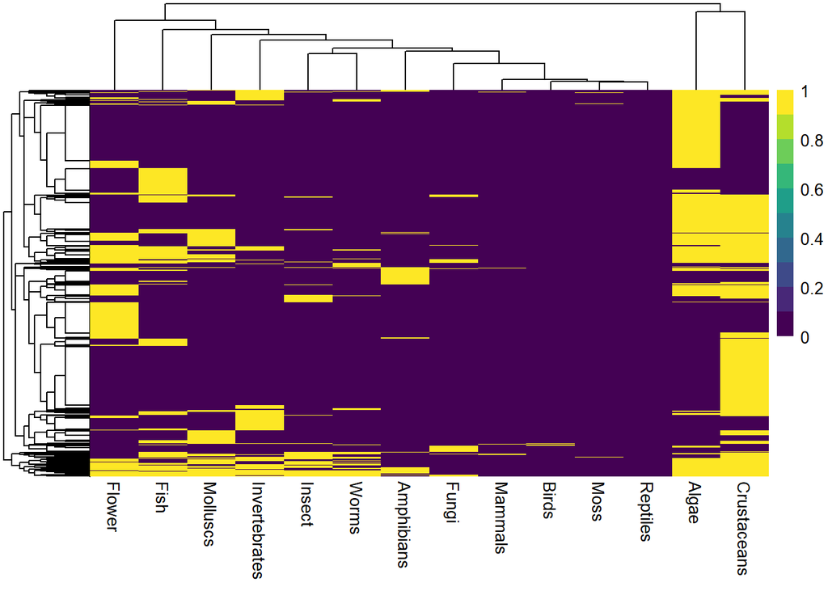

```
## [1] "LC50"
```

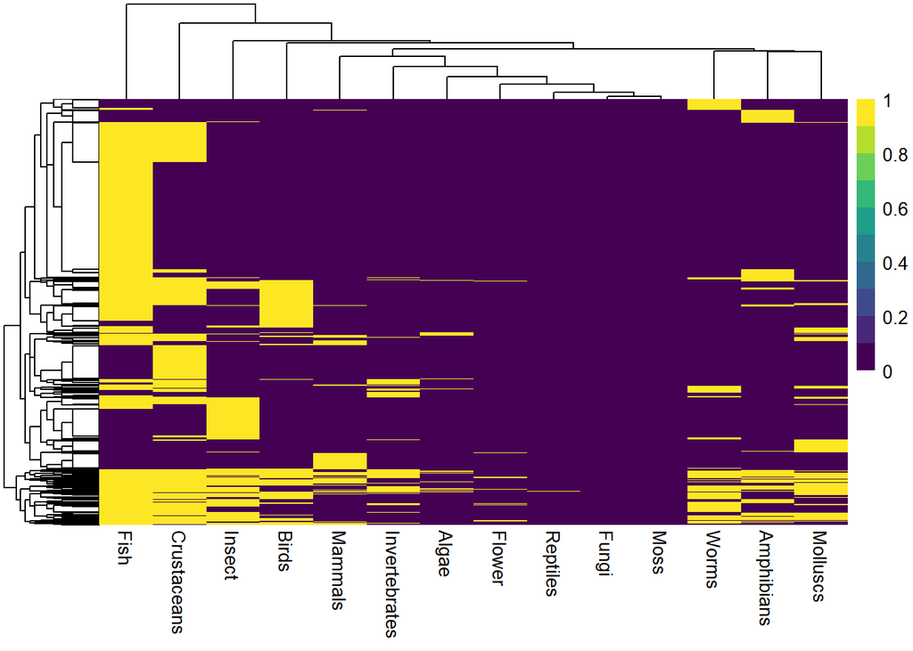

```
## [1] "LOEC"
```

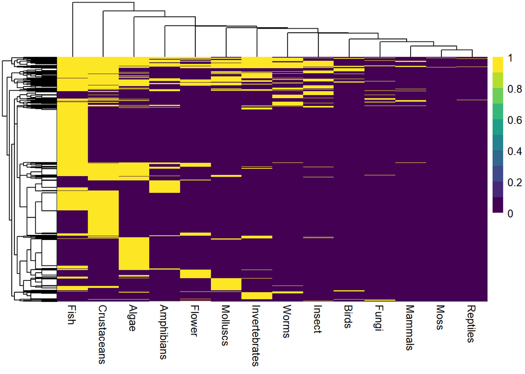

```
## [1] "NOEC"
```

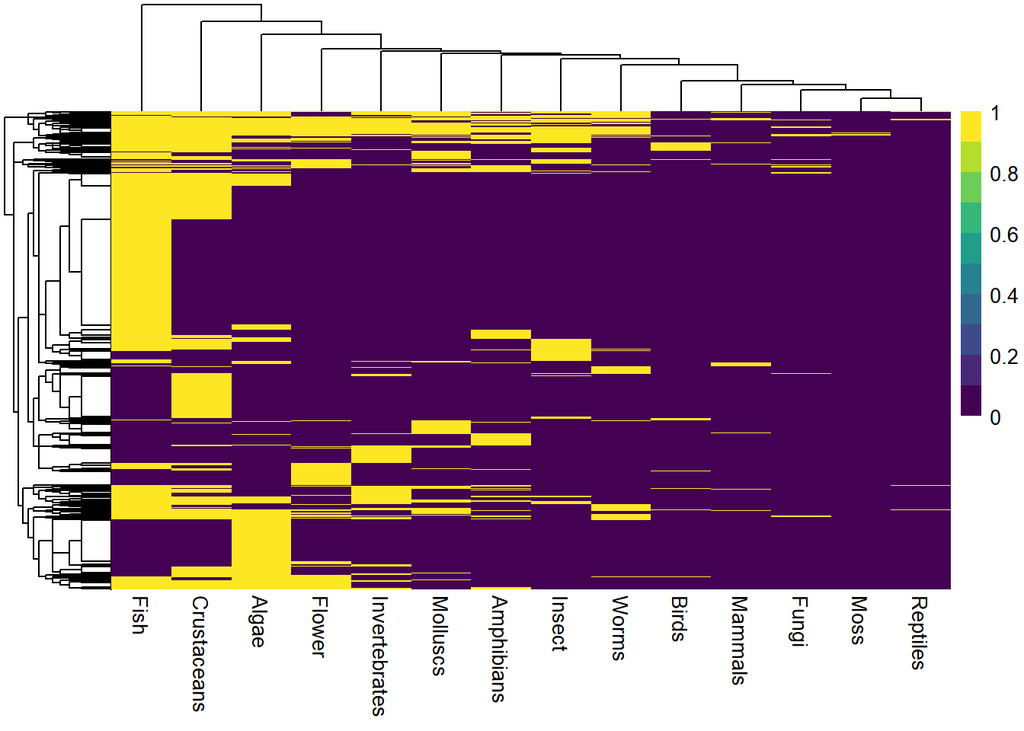

### 3.1.2 overall

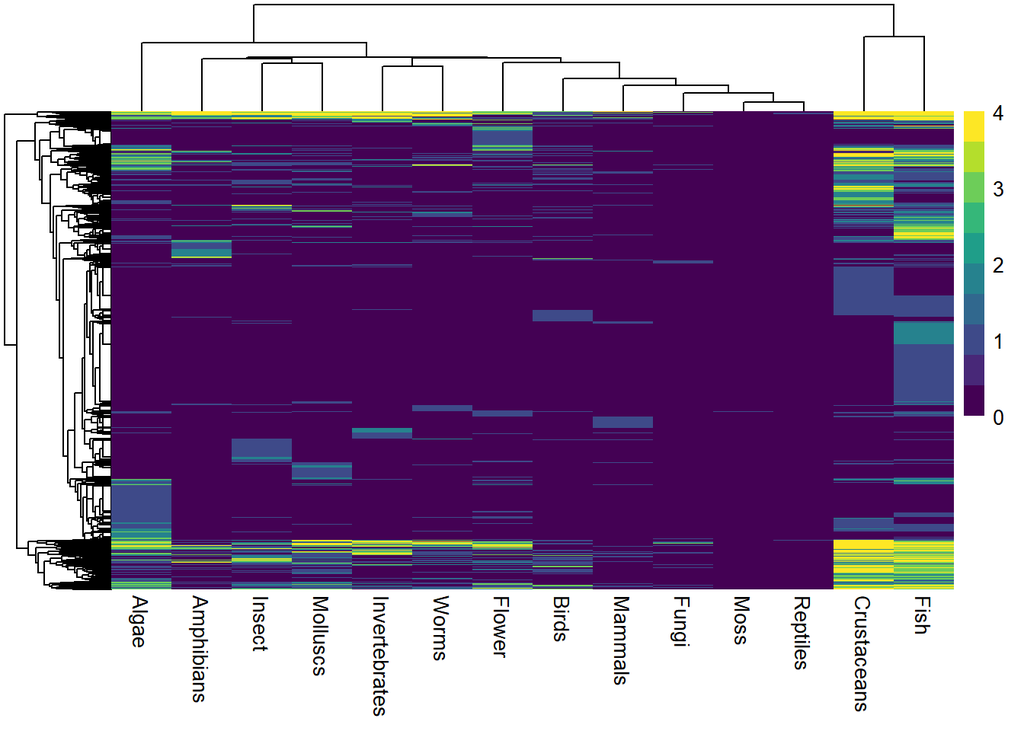

## 3.2 Rm groups under 50 entries

### 3.2.1 Initial counts

| Var1 | EC50 | LC50 | LOEC | NOEC |
| --- | --- | --- | --- | --- |
| Algae | 1826 | 148 | 796 | 857 |
| Amphibians | 290 | 659 | 380 | 374 |
| Birds | 11 | 918 | 94 | 92 |
| Crustaceans | 2033 | 2071 | 1097 | 1205 |
| Fish | 930 | 3255 | 1537 | 1687 |
| Flower | 1070 | 68 | 328 | 469 |
| Fungi | 182 | 3 | 79 | 60 |
| Insect | 326 | 1082 | 245 | 385 |
| Invertebrates | 566 | 378 | 364 | 428 |
| Mammals | 21 | 458 | 52 | 59 |
| Molluscs | 649 | 686 | 390 | 407 |
| Moss | 10 | 0 | 8 | 9 |
| Reptiles | 7 | 13 | 17 | 19 |
| Worms | 251 | 699 | 243 | 258 |

There are several datasets with representation under fifty entries.

### 3.2.2 After drop

| Var1 | EC50 | LC50 | LOEC | NOEC |
| --- | --- | --- | --- | --- |
| Algae | 1826 | 148 | 796 | 857 |
| Amphibians | 290 | 659 | 380 | 374 |
| Birds | 0 | 918 | 94 | 92 |
| Crustaceans | 2033 | 2071 | 1097 | 1205 |
| Fish | 930 | 3255 | 1537 | 1687 |
| Flower | 1070 | 68 | 328 | 469 |
| Fungi | 182 | 0 | 79 | 60 |
| Insect | 326 | 1082 | 245 | 385 |
| Invertebrates | 566 | 378 | 364 | 428 |
| Mammals | 0 | 458 | 52 | 59 |
| Molluscs | 649 | 686 | 390 | 407 |
| Moss | 0 | 0 | 0 | 0 |
| Reptiles | 0 | 0 | 0 | 0 |
| Worms | 251 | 699 | 243 | 258 |

### 3.2.3 Entry abundance

Considering the relative abundance of entries without those datasets under 50 entries.

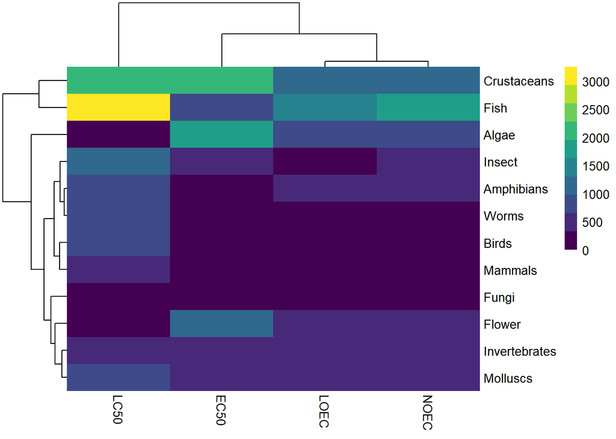

Underentered groups dropped and column scaled representation

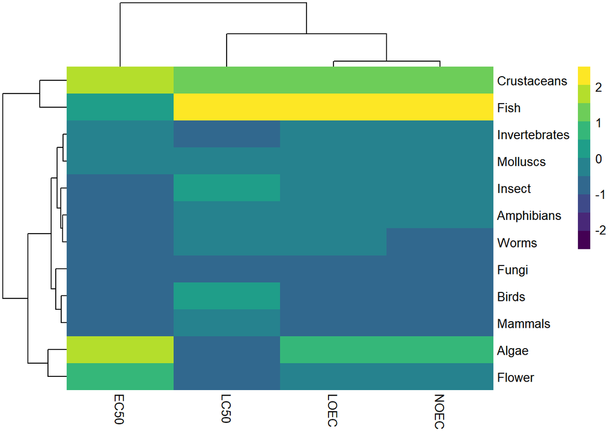

### 3.2.4 frequency table

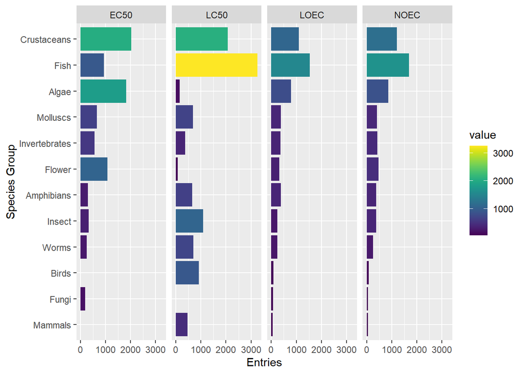

## 3.3 what do the values look like for remaining groups?

### 3.3.1 inital

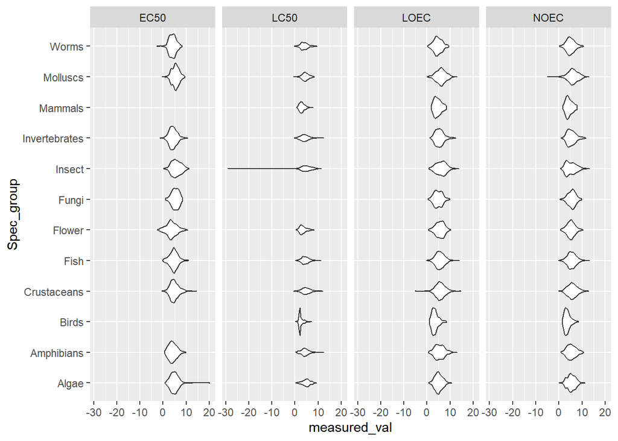

There are `118` entries dropped due to groupwise underrepresentation at a 50 entry threshold.

I find it weird that there is a negative LC50 reported for at least one group, Insects. I checked the original excel sheet and a value of -29 is entered. ???

### 3.3.2 Final

When values under 0.0000005 are removed the plot appears as:

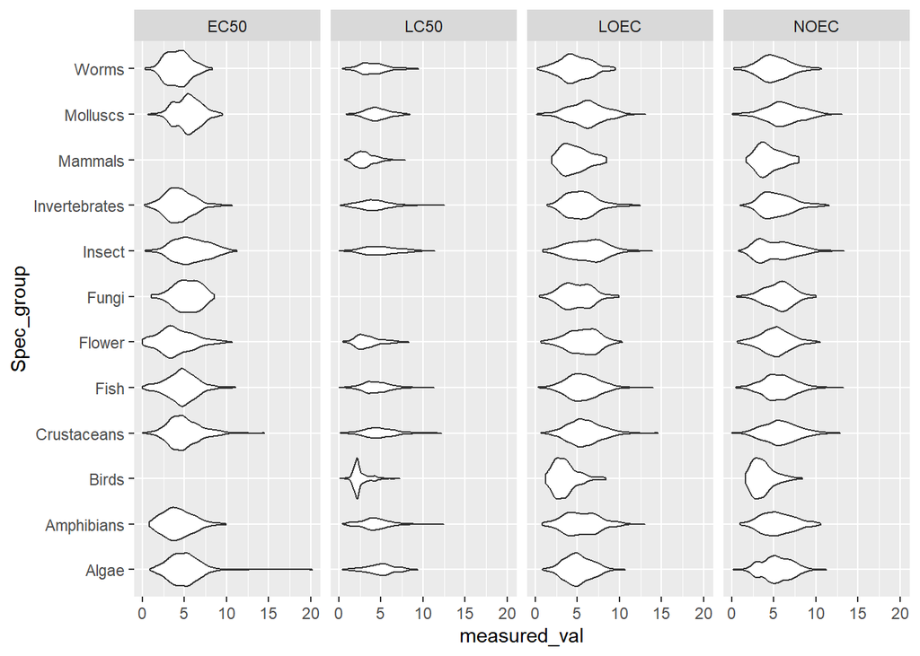

## 3.4 Summary

There are `6540` unique compounds represented across `12` groups of species over four endpoint types `EC50, LC50, NOEC, LOEC` for a total of `45` species * endpoint combinations which will be used to make individual models.

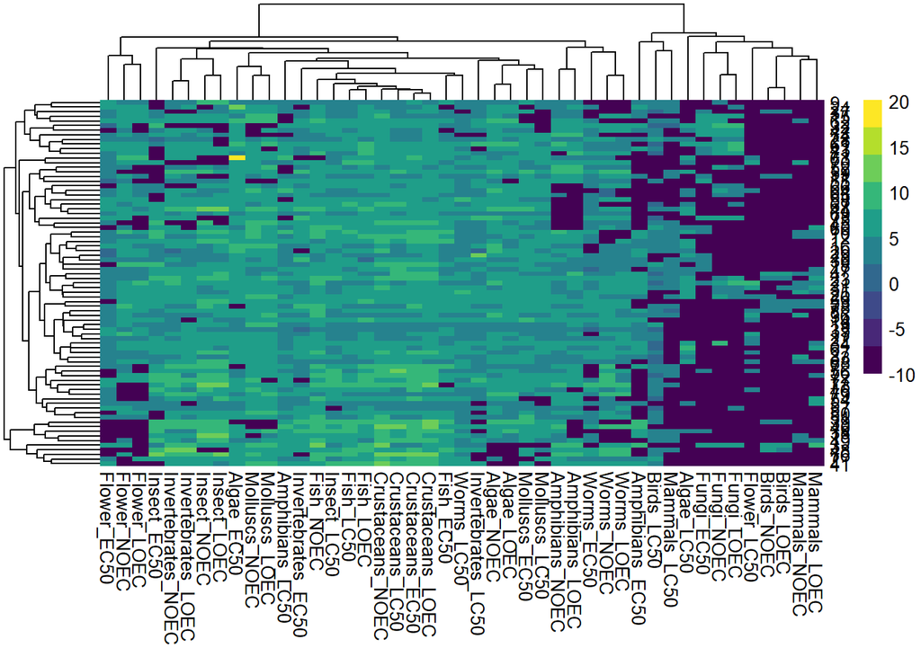

# 4 Fin